# day 3-1

このノートブックの実行例はこちら(HTML版)で確認できます

## 0. 準備

### 0.1 必要なパッケージのインストール

```python
%%capture
!sudo apt-get update
!sudo apt-get install -y automake autoconf perl libtool graphviz libgraphviz-dev
!pip install -U japanize_matplotlib pyvis pygraphviz mca
```

教材のダウンロード

```python
!git clone https://github.com/haradatm/lecture-gssm2025
```

```
Cloning into 'lecture-gssm2025'...
remote: Enumerating objects: 110, done.
remote: Counting objects: 100% (12/12), done.
remote: Compressing objects: 100% (10/10), done.
remote: Total 110 (delta 3), reused 8 (delta 2), pack-reused 98 (from 2)
Receiving objects: 100% (110/110), 71.32 MiB | 28.25 MiB/s, done.
Resolving deltas: 100% (40/40), done.
```

### 0.2 MeCab インストール (時間目安: 約3分)

```python
%%time
!bash lecture-gssm2025/scripts/install_mecab.sh >> install_mecab.log 2>&1
!tail -n 1 install_mecab.log
```

```
CPU times: user 1.25 s, sys: 196 ms, total: 1.44 s
Wall time: 3min 2s
```

### 0.3 CaboCha インストール (時間目安: 約4分)

```python
%%time
!bash lecture-gssm2025/scripts/install_cabocha.sh >> install_cabocha.log 2>&1
!tail -n 1 install_cabocha.log
```

```
CPU times: user 2.01 s, sys: 303 ms, total: 2.31 s
Wall time: 4min 45s
```

### 0.4 セッションの再起動

```python
import os
os.kill(os.getpid(), 9)
```

セッションの再起動後は,以下のセルから実行してください. **注意: これより前のセルを再度実行する必要はありません!**

### 0.5 動作確認

```python
import MeCab
tagger = MeCab.Tagger("-r ./tools/usr/local/etc/mecabrc")
print(tagger.parse("今日はいい天気です"))
```

```
今日	名詞,副詞可能,*,*,*,*,今日,キョウ,キョー
は	助詞,係助詞,*,*,*,*,は,ハ,ワ
いい	形容詞,自立,*,*,形容詞・イイ,基本形,いい,イイ,イイ
天気	名詞,一般,*,*,*,*,天気,テンキ,テンキ
です	助動詞,*,*,*,特殊・デス,基本形,です,デス,デス
EOS
```

```python
import CaboCha
cp = CaboCha.Parser("-r ./tools/usr/local/etc/cabocharc")
tree = cp.parse("今日はいい天気です")
print(tree.toString(CaboCha.FORMAT_LATTICE))
```

```
* 0 2D 0/1 -1.041733
今日	名詞,副詞可能,*,*,*,*,今日,キョウ,キョー
は	助詞,係助詞,*,*,*,*,は,ハ,ワ
* 1 2D 0/0 -1.041733
いい	形容詞,自立,*,*,形容詞・イイ,基本形,いい,イイ,イイ
* 2 -1D 0/1 0.000000
天気	名詞,一般,*,*,*,*,天気,テンキ,テンキ
です	助動詞,*,*,*,特殊・デス,基本形,です,デス,デス
EOS
```

## 1. テキスト解析 (1)

```python
%load_ext autoreload
%autoreload 2

import os
import random
import numpy as np

# 再現性のために乱数を固定する
seed = 42
os.environ['PYTHONHASHSEED'] = str(seed)
np.random.seed(seed)
random.seed(seed)
```

### 1.1 形態素解析

(1) そのまま実行する

```python
import MeCab
tagger = MeCab.Tagger("-r ./tools/usr/local/etc/mecabrc")
print(tagger.parse("今日はいい天気です"))
```

```
今日	名詞,副詞可能,*,*,*,*,今日,キョウ,キョー
は	助詞,係助詞,*,*,*,*,は,ハ,ワ
いい	形容詞,自立,*,*,形容詞・イイ,基本形,いい,イイ,イイ
天気	名詞,一般,*,*,*,*,天気,テンキ,テンキ
です	助動詞,*,*,*,特殊・デス,基本形,です,デス,デス
EOS
```

(2) 扱いやすいように Pandas の DataFrame に格納する

```python
import pandas as pd

node = tagger.parseToNode("今日はいい天気です")
features = []
while node:
    features.append(node.feature.split(','))
    node = node.next

columns = [
    "品詞",
    "品詞細分類1",
    "品詞細分類2",
    "品詞細分類3",
    "活用型",
    "活用形",
    "基本形",
    "読み",
    "発音",
]
pd.DataFrame(features, columns=columns)
```

|  | 品詞 | 品詞細分類1 | 品詞細分類2 | 品詞細分類3 | 活用型 | 活用形 | 基本形 | 読み | 発音 |
| --- | --- | --- | --- | --- | --- | --- | --- | --- | --- |
| 0 | BOS/EOS | * | * | * | * | * | * | * | * |
| 1 | 名詞 | 副詞可能 | * | * | * | * | 今日 | キョウ | キョー |
| 2 | 助詞 | 係助詞 | * | * | * | * | は | ハ | ワ |
| 3 | 形容詞 | 自立 | * | * | 形容詞・イイ | 基本形 | いい | イイ | イイ |
| 4 | 名詞 | 一般 | * | * | * | * | 天気 | テンキ | テンキ |
| 5 | 助動詞 | * | * | * | 特殊・デス | 基本形 | です | デス | デス |
| 6 | BOS/EOS | * | * | * | * | * | * | * | * |

### 1.2 係り受け解析

(1) そのまま実行する

```python
import CaboCha
cp = CaboCha.Parser("-r ./tools/usr/local/etc/cabocharc")
tree = cp.parse("今日はいい天気です")
print(tree.toString(CaboCha.FORMAT_LATTICE))
```

```
* 0 2D 0/1 -1.041733
今日	名詞,副詞可能,*,*,*,*,今日,キョウ,キョー
は	助詞,係助詞,*,*,*,*,は,ハ,ワ
* 1 2D 0/0 -1.041733
いい	形容詞,自立,*,*,形容詞・イイ,基本形,いい,イイ,イイ
* 2 -1D 0/1 0.000000
天気	名詞,一般,*,*,*,*,天気,テンキ,テンキ
です	助動詞,*,*,*,特殊・デス,基本形,です,デス,デス
EOS
```

(2) ツリー形式で出力する

```python
print(cp.parseToString("今日はいい天気です"))
```

```
  今日は---D
      いい-D
    天気です
EOS
```

(3) 係り受けペアを出力する

```python
# 構文木(tree)からチャンクを取り出す
def get_chunks(tree):
    chunks = {}
    key = 0
    for i in range(tree.size()):
        tok = tree.token(i)
        if tok.chunk:
            chunks[key] = tok.chunk
            key += 1
    return chunks


# チャンク(chunk)から表層形を取り出す
def get_surface(chunk):
    surface = ""
    beg = chunk.token_pos
    end = chunk.token_pos + chunk.token_size
    for i in range(beg, end):
        token = tree.token(i)
        surface += token.surface
    return surface
```

```python
tree = cp.parse("今日はいい天気です")
chunks = get_chunks(tree)

for from_chunk in chunks.values():
    if from_chunk.link < 0:
        continue
    to_chunk = chunks[from_chunk.link]

    from_surface = get_surface(from_chunk)
    to_surface = get_surface(to_chunk)

    print(from_surface, '->', to_surface)
```

```
今日は -> 天気です
いい -> 天気です
```

### 1.3 辞書追加

(1) 辞書追加前に MeCab の解析結果を確認する

```python
import MeCab

tagger = MeCab.Tagger("-r ./tools/usr/local/etc/mecabrc")
print(tagger.parse("この泉質は極上です"))
print(tagger.parse("この海鮮丼は美味しいです"))
print(tagger.parse("近くにスカイツリーがあります"))
print(tagger.parse("浴室にバスタオルがありません"))
```

```
この	連体詞,*,*,*,*,*,この,コノ,コノ
泉	名詞,一般,*,*,*,*,泉,イズミ,イズミ
質	名詞,接尾,一般,*,*,*,質,シツ,シツ
は	助詞,係助詞,*,*,*,*,は,ハ,ワ
極上	名詞,一般,*,*,*,*,極上,ゴクジョウ,ゴクジョー
です	助動詞,*,*,*,特殊・デス,基本形,です,デス,デス
EOS

この	連体詞,*,*,*,*,*,この,コノ,コノ
海鮮	名詞,一般,*,*,*,*,海鮮,カイセン,カイセン
丼	名詞,一般,*,*,*,*,丼,ドンブリ,ドンブリ
は	助詞,係助詞,*,*,*,*,は,ハ,ワ
美味しい	形容詞,自立,*,*,形容詞・イ段,基本形,美味しい,オイシイ,オイシイ
です	助動詞,*,*,*,特殊・デス,基本形,です,デス,デス
EOS

近く	名詞,副詞可能,*,*,*,*,近く,チカク,チカク
に	助詞,格助詞,一般,*,*,*,に,ニ,ニ
スカイ	名詞,一般,*,*,*,*,スカイ,スカイ,スカイ
ツリー	名詞,一般,*,*,*,*,ツリー,ツリー,ツリー
が	助詞,格助詞,一般,*,*,*,が,ガ,ガ
あり	動詞,自立,*,*,五段・ラ行,連用形,ある,アリ,アリ
ます	助動詞,*,*,*,特殊・マス,基本形,ます,マス,マス
EOS

浴室	名詞,一般,*,*,*,*,浴室,ヨクシツ,ヨクシツ
に	助詞,格助詞,一般,*,*,*,に,ニ,ニ
バス	名詞,一般,*,*,*,*,バス,バス,バス
タオル	名詞,一般,*,*,*,*,タオル,タオル,タオル
が	助詞,格助詞,一般,*,*,*,が,ガ,ガ
あり	動詞,自立,*,*,五段・ラ行,連用形,ある,アリ,アリ
ませ	助動詞,*,*,*,特殊・マス,未然形,ます,マセ,マセ
ん	助動詞,*,*,*,不変化型,基本形,ん,ン,ン
EOS
```

(2) 辞書追加前に CaboCha の解析結果を確認する

```python
import CaboCha

cp = CaboCha.Parser("-r ./tools/usr/local/etc/cabocharc")
print(cp.parse("この泉質は極上です").toString(CaboCha.FORMAT_LATTICE))
print(cp.parse("この海鮮丼は美味しいです").toString(CaboCha.FORMAT_LATTICE))
print(cp.parse("近くにスカイツリーがあります").toString(CaboCha.FORMAT_LATTICE))
print(cp.parse("浴室にバスタオルがありません").toString(CaboCha.FORMAT_LATTICE))
```

```
* 0 1D 0/0 1.423997
この	連体詞,*,*,*,*,*,この,コノ,コノ
* 1 2D 1/2 1.423997
泉	名詞,一般,*,*,*,*,泉,イズミ,イズミ
質	名詞,接尾,一般,*,*,*,質,シツ,シツ
は	助詞,係助詞,*,*,*,*,は,ハ,ワ
* 2 -1D 0/1 0.000000
極上	名詞,一般,*,*,*,*,極上,ゴクジョウ,ゴクジョー
です	助動詞,*,*,*,特殊・デス,基本形,です,デス,デス
EOS

* 0 1D 0/0 1.479074
この	連体詞,*,*,*,*,*,この,コノ,コノ
* 1 2D 1/2 1.479074
海鮮	名詞,一般,*,*,*,*,海鮮,カイセン,カイセン
丼	名詞,一般,*,*,*,*,丼,ドンブリ,ドンブリ
は	助詞,係助詞,*,*,*,*,は,ハ,ワ
* 2 -1D 0/1 0.000000
美味しい	形容詞,自立,*,*,形容詞・イ段,基本形,美味しい,オイシイ,オイシイ
です	助動詞,*,*,*,特殊・デス,基本形,です,デス,デス
EOS

* 0 2D 0/1 -2.105621
近く	名詞,副詞可能,*,*,*,*,近く,チカク,チカク
に	助詞,格助詞,一般,*,*,*,に,ニ,ニ
* 1 2D 1/2 -2.105621
スカイ	名詞,一般,*,*,*,*,スカイ,スカイ,スカイ
ツリー	名詞,一般,*,*,*,*,ツリー,ツリー,ツリー
が	助詞,格助詞,一般,*,*,*,が,ガ,ガ
* 2 -1D 0/1 0.000000
あり	動詞,自立,*,*,五段・ラ行,連用形,ある,アリ,アリ
ます	助動詞,*,*,*,特殊・マス,基本形,ます,マス,マス
EOS

* 0 2D 0/1 -1.725976
浴室	名詞,一般,*,*,*,*,浴室,ヨクシツ,ヨクシツ
に	助詞,格助詞,一般,*,*,*,に,ニ,ニ
* 1 2D 1/2 -1.725976
バス	名詞,一般,*,*,*,*,バス,バス,バス
タオル	名詞,一般,*,*,*,*,タオル,タオル,タオル
が	助詞,格助詞,一般,*,*,*,が,ガ,ガ
* 2 -1D 0/2 0.000000
あり	動詞,自立,*,*,五段・ラ行,連用形,ある,アリ,アリ
ませ	助動詞,*,*,*,特殊・マス,未然形,ます,マセ,マセ
ん	助動詞,*,*,*,不変化型,基本形,ん,ン,ン
EOS
```

(3) 追加したい形態素の情報を CSV ファイル(user_dic.csv)に追記する

```python
!echo '"泉質",-1,-1,1,名詞,一般,*,*,*,*,泉質,センシツ,センシツ,USER"' >> ./tools/usr/local/lib/mecab/dic/ipadic/user_dic.csv
!echo '"海鮮丼",-1,-1,1,名詞,一般,*,*,*,*,海鮮丼,カイセンドン,カイセンドン,USER"' >> ./tools/usr/local/lib/mecab/dic/ipadic/user_dic.csv
!echo '"スカイツリー",-1,-1,1,名詞,一般,*,*,*,*,スカイツリー,スカイツリー,スカイツリー,USER"' >> ./tools/usr/local/lib/mecab/dic/ipadic/user_dic.csv
!echo '"バスタオル",-1,-1,1,名詞,一般,*,*,*,*,バスタオル,バスタオル,バスタオル,USER"' >> ./tools/usr/local/lib/mecab/dic/ipadic/user_dic.csv
!cat ./tools/usr/local/lib/mecab/dic/ipadic/user_dic.csv
```

```
"湯畑",-1,-1,1,名詞,一般,*,*,*,*,湯畑,ユバタケ,ユバタケ,USER"
"泉質",-1,-1,1,名詞,一般,*,*,*,*,泉質,センシツ,センシツ,USER"
"海鮮丼",-1,-1,1,名詞,一般,*,*,*,*,海鮮丼,カイセンドン,カイセンドン,USER"
"スカイツリー",-1,-1,1,名詞,一般,*,*,*,*,スカイツリー,スカイツリー,スカイツリー,USER"
"バスタオル",-1,-1,1,名詞,一般,*,*,*,*,バスタオル,バスタオル,バスタオル,USER"
```

(4) CSVファイル(user_dic.csv)をコンパイルして辞書(user.dic)を作成する

```python
!./tools/usr/local/libexec/mecab/mecab-dict-index \
-d ./tools/usr/local/lib/mecab/dic/ipadic \
-u ./tools/usr/local/lib/mecab/dic/ipadic/user.dic \
-f utf-8 -t utf-8 \
./tools/usr/local/lib/mecab/dic/ipadic/user_dic.csv
```

(5) 辞書追加後に MeCab の解析結果を確認する

```python
import MeCab

tagger = MeCab.Tagger("-r ./tools/usr/local/etc/mecabrc")
print(tagger.parse("この泉質は極上です"))
print(tagger.parse("この海鮮丼は美味しいです"))
print(tagger.parse("近くにスカイツリーがあります"))
print(tagger.parse("浴室にバスタオルがありません"))
```

```
この	連体詞,*,*,*,*,*,この,コノ,コノ
泉	名詞,一般,*,*,*,*,泉,イズミ,イズミ
質	名詞,接尾,一般,*,*,*,質,シツ,シツ
は	助詞,係助詞,*,*,*,*,は,ハ,ワ
極上	名詞,一般,*,*,*,*,極上,ゴクジョウ,ゴクジョー
です	助動詞,*,*,*,特殊・デス,基本形,です,デス,デス
EOS

この	連体詞,*,*,*,*,*,この,コノ,コノ
海鮮	名詞,一般,*,*,*,*,海鮮,カイセン,カイセン
丼	名詞,一般,*,*,*,*,丼,ドンブリ,ドンブリ
は	助詞,係助詞,*,*,*,*,は,ハ,ワ
美味しい	形容詞,自立,*,*,形容詞・イ段,基本形,美味しい,オイシイ,オイシイ
です	助動詞,*,*,*,特殊・デス,基本形,です,デス,デス
EOS

近く	名詞,副詞可能,*,*,*,*,近く,チカク,チカク
に	助詞,格助詞,一般,*,*,*,に,ニ,ニ
スカイ	名詞,一般,*,*,*,*,スカイ,スカイ,スカイ
ツリー	名詞,一般,*,*,*,*,ツリー,ツリー,ツリー
が	助詞,格助詞,一般,*,*,*,が,ガ,ガ
あり	動詞,自立,*,*,五段・ラ行,連用形,ある,アリ,アリ
ます	助動詞,*,*,*,特殊・マス,基本形,ます,マス,マス
EOS

浴室	名詞,一般,*,*,*,*,浴室,ヨクシツ,ヨクシツ
に	助詞,格助詞,一般,*,*,*,に,ニ,ニ
バス	名詞,一般,*,*,*,*,バス,バス,バス
タオル	名詞,一般,*,*,*,*,タオル,タオル,タオル
が	助詞,格助詞,一般,*,*,*,が,ガ,ガ
あり	動詞,自立,*,*,五段・ラ行,連用形,ある,アリ,アリ
ませ	助動詞,*,*,*,特殊・マス,未然形,ます,マセ,マセ
ん	助動詞,*,*,*,不変化型,基本形,ん,ン,ン
EOS
```

(6) 辞書追加後に CaboCha の解析結果を確認する

```python
import CaboCha

cp = CaboCha.Parser("-r ./tools/usr/local/etc/cabocharc")
print(cp.parse("この泉質は極上です").toString(CaboCha.FORMAT_LATTICE))
print(cp.parse("この海鮮丼は美味しいです").toString(CaboCha.FORMAT_LATTICE))
print(cp.parse("近くにスカイツリーがあります").toString(CaboCha.FORMAT_LATTICE))
print(cp.parse("浴室にバスタオルがありません").toString(CaboCha.FORMAT_LATTICE))
```

```
* 0 1D 0/0 1.423997
この	連体詞,*,*,*,*,*,この,コノ,コノ
* 1 2D 1/2 1.423997
泉	名詞,一般,*,*,*,*,泉,イズミ,イズミ
質	名詞,接尾,一般,*,*,*,質,シツ,シツ
は	助詞,係助詞,*,*,*,*,は,ハ,ワ
* 2 -1D 0/1 0.000000
極上	名詞,一般,*,*,*,*,極上,ゴクジョウ,ゴクジョー
です	助動詞,*,*,*,特殊・デス,基本形,です,デス,デス
EOS

* 0 1D 0/0 1.479074
この	連体詞,*,*,*,*,*,この,コノ,コノ
* 1 2D 1/2 1.479074
海鮮	名詞,一般,*,*,*,*,海鮮,カイセン,カイセン
丼	名詞,一般,*,*,*,*,丼,ドンブリ,ドンブリ
は	助詞,係助詞,*,*,*,*,は,ハ,ワ
* 2 -1D 0/1 0.000000
美味しい	形容詞,自立,*,*,形容詞・イ段,基本形,美味しい,オイシイ,オイシイ
です	助動詞,*,*,*,特殊・デス,基本形,です,デス,デス
EOS

* 0 2D 0/1 -2.105621
近く	名詞,副詞可能,*,*,*,*,近く,チカク,チカク
に	助詞,格助詞,一般,*,*,*,に,ニ,ニ
* 1 2D 1/2 -2.105621
スカイ	名詞,一般,*,*,*,*,スカイ,スカイ,スカイ
ツリー	名詞,一般,*,*,*,*,ツリー,ツリー,ツリー
が	助詞,格助詞,一般,*,*,*,が,ガ,ガ
* 2 -1D 0/1 0.000000
あり	動詞,自立,*,*,五段・ラ行,連用形,ある,アリ,アリ
ます	助動詞,*,*,*,特殊・マス,基本形,ます,マス,マス
EOS

* 0 2D 0/1 -1.725976
浴室	名詞,一般,*,*,*,*,浴室,ヨクシツ,ヨクシツ
に	助詞,格助詞,一般,*,*,*,に,ニ,ニ
* 1 2D 1/2 -1.725976
バス	名詞,一般,*,*,*,*,バス,バス,バス
タオル	名詞,一般,*,*,*,*,タオル,タオル,タオル
が	助詞,格助詞,一般,*,*,*,が,ガ,ガ
* 2 -1D 0/2 0.000000
あり	動詞,自立,*,*,五段・ラ行,連用形,ある,アリ,アリ
ませ	助動詞,*,*,*,特殊・マス,未然形,ます,マセ,マセ
ん	助動詞,*,*,*,不変化型,基本形,ん,ン,ン
EOS
```

## Appendix. データ理解 (Python の場合)

### A.1 データのダウンロード

以下のデータをダウンロードします

| ファイル名 | 件数 | データセット | 備考 |
| --- | --- | --- | --- |
| rakuten-1000-2024-2025.xlsx.zip | 10,000 | •レジャー+ビジネスの 10エリア •エリアごと 1,000件 (ランダムサンプリング) •期間: 2024/1~2025 GW明け | 本講義の全体を通して使用する |

```python
# rakuten-1000-2024-2025.xlsx.zip をダウンロードする
FILE_ID = "1yKabZ7qJMRrIrP4Vtq-RrSZAqFsZriQS"
!gdown {FILE_ID}
!unzip -o rakuten-1000-2024-2025.xlsx.zip
```

```
Downloading...
From: https://drive.google.com/uc?id=1yKabZ7qJMRrIrP4Vtq-RrSZAqFsZriQS
To: /content/rakuten-1000-2024-2025.xlsx.zip

  0% 0.00/2.61M [00:00<?, ?B/s]
100% 2.61M/2.61M [00:00<00:00, 58.1MB/s]
Archive:  rakuten-1000-2024-2025.xlsx.zip
  inflating: rakuten-1000-2024-2025.xlsx
```

### A.2 データの読み込み (DataFrame型)

```python
import numpy as np
import pandas as pd

df = pd.read_excel("rakuten-1000-2024-2025.xlsx")
print(df.shape)
display(df.head())
```

```
(10000, 19)
```

|  | カテゴリー | エリア | 施設番号 | 施設名 | コメント | 総合 | サービス | 立地 | 部屋 | 設備・アメニティ | 風呂 | 食事 | 旅行の目的 | 同伴者 | 宿泊年月 | 投稿者 | 年代 | 性別 | 投稿日 |
| --- | --- | --- | --- | --- | --- | --- | --- | --- | --- | --- | --- | --- | --- | --- | --- | --- | --- | --- | --- |
| 0 | A_レジャー | 01_登別 | 29995 | ゆとりろ洞爺湖 | わんこと泊まれて良かった！ | 3 | 3 | 3 | 3 | 3.0 | 4.0 | 3.0 | レジャー | 家族 | 45413 | 投稿者 | na | na | 45445.668553 |
| 1 | A_レジャー | 01_登別 | 9691 | 登別温泉 ホテルゆもと登別 | 古い建物ですがきれいにしている感じでした。入った瞬間においが気になりましたが、タバコのにおい... | 5 | 5 | 5 | 4 | 5.0 | 4.0 | 5.0 | レジャー | 家族 | 45474 | mamemama3 | 40代 | 女性 | 45499.742442 |
| 2 | A_レジャー | 01_登別 | 40708 | 虎杖浜温泉 ホテル いずみ | 3月15日に初めて宿泊させて頂きました。予約プランは和室6畳でしたが、空きがあるとのことで1... | 5 | 5 | 5 | 5 | 5.0 | 5.0 | 5.0 | レジャー | 家族 | 45717 | ハコ9437 | 40代 | 女性 | 45733.810486 |
| 3 | A_レジャー | 01_登別 | 139962 | ザ レイクビュー ＴＯＹＡ 乃の風リゾート | 大きめ柴犬と宿泊しましたが、部屋は充分な広さでした夕朝食のブッフェも、種類豊富で美味しかった... | 4 | 5 | 5 | 4 | 4.0 | 4.0 | 5.0 | レジャー | 家族 | 45413 | 投稿者 | na | na | 45440.662477 |
| 4 | A_レジャー | 01_登別 | 168374 | 虎杖浜天然温泉 「旅人の湯」ホテルルートインＧｒａｎｄ室蘭 | コーヒー無料サービスが嬉しい。水のペットボトルサービスがあるとさらに良い（最近デフォルトのビ... | 4 | 3 | 4 | 4 | 3.0 | 3.0 | NaN | ビジネス | 一人 | 45505 | 投稿者 | na | na | 45529.484410 |

### A.3 集計

#### (1) エリア別の件数を表示する

```python
display(df.pivot_table(index=['カテゴリー','エリア'], columns=None, values='コメント', aggfunc='count'))
```

| カテゴリー | エリア | コメント |
| --- | --- | --- |
| A_レジャー | 01_登別 | 1000 |
|  | 02_草津 | 1000 |
|  | 03_箱根 | 1000 |
|  | 04_道後 | 1000 |
|  | 05_湯布院 | 1000 |
| B_ビジネス | 06_札幌 | 1000 |
|  | 07_名古屋 | 1000 |
|  | 08_東京 | 1000 |
|  | 09_大阪 | 1000 |
|  | 10_福岡 | 1000 |

サンプリングデータなので、すべて1000件になっていることを確認する

#### (2) 投稿者の傾向 (年代別x性別、全体で100%)

```python
cross_df = pd.crosstab(df['年代'], df['性別'], margins=True, margins_name='合計', normalize=True) * 100
display(cross_df.loc[:,['男性','女性','na','合計']].style.format('{:.2f}%').bar(axis=None, vmin=0, width=90, height=90, align='left'))
```

| 性別 年代 | 男性 | 女性 | na | 合計 |
| --- | --- | --- | --- | --- |
| 10代 | 0.01% | 0.04% | 0.00% | 0.05% |
| 120代 | 0.00% | 0.01% | 0.00% | 0.01% |
| 20代 | 0.58% | 1.14% | 0.00% | 1.72% |
| 30代 | 2.00% | 2.40% | 0.00% | 4.40% |
| 40代 | 4.15% | 3.22% | 0.00% | 7.37% |
| 50代 | 8.06% | 4.06% | 0.00% | 12.12% |
| 60代 | 6.33% | 2.61% | 0.00% | 8.94% |
| 70代 | 1.54% | 0.46% | 0.00% | 2.00% |
| 80代 | 0.07% | 0.04% | 0.00% | 0.11% |
| 90代 | 0.01% | 0.00% | 0.00% | 0.01% |
| na | 0.00% | 0.00% | 63.27% | 63.27% |
| 合計 | 22.75% | 13.98% | 63.27% | 100.00% |

`na` を除いて表示する

```python
cross_df = pd.crosstab(df['年代'], df['性別'], margins=False, normalize=True) * 100
display(cross_df.loc[cross_df.index!='na',['男性','女性']].style.format('{:.2f}%').bar(axis=None, vmin=0, width=90, height=90, align='left'))
```

| 性別 年代 | 男性 | 女性 |
| --- | --- | --- |
| 10代 | 0.01% | 0.04% |
| 120代 | 0.00% | 0.01% |
| 20代 | 0.58% | 1.14% |
| 30代 | 2.00% | 2.40% |
| 40代 | 4.15% | 3.22% |
| 50代 | 8.06% | 4.06% |
| 60代 | 6.33% | 2.61% |
| 70代 | 1.54% | 0.46% |
| 80代 | 0.07% | 0.04% |
| 90代 | 0.01% | 0.00% |

#### (3) 投稿者の傾向 (性別xカテゴリ別、列ごとで100%)

```python
cross_df = pd.crosstab(df['性別'], df['カテゴリー'], margins=True, margins_name='合計', normalize='columns') * 100
display(cross_df.loc[['男性','女性','na'],:].style.format('{:.2f}%').bar(axis=None, width=90, height=90, align='left'))
```

| カテゴリー 性別 | A_レジャー | B_ビジネス | 合計 |
| --- | --- | --- | --- |
| 男性 | 21.52% | 23.98% | 22.75% |
| 女性 | 16.80% | 11.16% | 13.98% |
| na | 61.68% | 64.86% | 63.27% |

`na` を除いて表示する

```python
cross_df = pd.crosstab(df['性別'], df['カテゴリー'], margins=False, normalize='columns') * 100
display(cross_df.loc[['男性','女性'],:].style.format('{:.2f}%').bar(axis=None, vmin=0, width=90, height=90, align='left'))
```

| カテゴリー 性別 | A_レジャー | B_ビジネス |
| --- | --- | --- |
| 男性 | 21.52% | 23.98% |
| 女性 | 16.80% | 11.16% |

#### (4) 投稿者の傾向 (性別xエリア別、列ごとで100%)

```python
cross_df = pd.crosstab(df['性別'], [df['カテゴリー'],df['エリア']], margins=True, margins_name='合計', normalize='columns') * 100
display(cross_df.loc[['男性','女性','na'],:].style.format('{:.2f}%'))
```

| カテゴリー エリア 性別 | A_レジャー 01_登別 | A_レジャー 02_草津 | A_レジャー 03_箱根 | A_レジャー 04_道後 | A_レジャー 05_湯布院 | B_ビジネス 06_札幌 | B_ビジネス 07_名古屋 | B_ビジネス 08_東京 | B_ビジネス 09_大阪 | B_ビジネス 10_福岡 | 合計 |
| --- | --- | --- | --- | --- | --- | --- | --- | --- | --- | --- | --- |
| 男性 | 24.40% | 21.20% | 15.80% | 26.50% | 19.70% | 25.90% | 26.00% | 20.80% | 23.60% | 23.60% | 22.75% |
| 女性 | 16.80% | 17.40% | 18.30% | 13.00% | 18.50% | 10.90% | 9.90% | 11.60% | 10.50% | 12.90% | 13.98% |
| na | 58.80% | 61.40% | 65.90% | 60.50% | 61.80% | 63.20% | 64.10% | 67.60% | 65.90% | 63.50% | 63.27% |

カラーバーにすると横に長くなるため、ヒートマップでプロットする

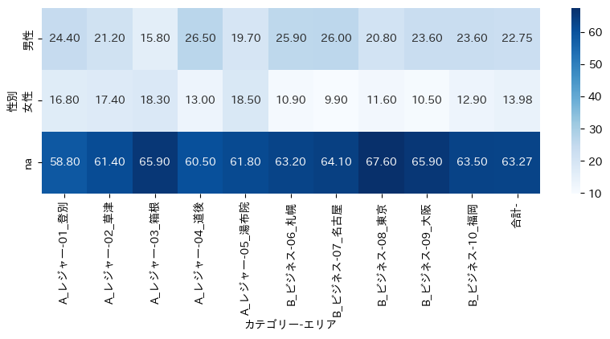

```python
import seaborn as sns
import matplotlib.pyplot as plt
import japanize_matplotlib

plt.figure(figsize=(10,3))
sns.heatmap(cross_df.loc[['男性','女性','na'],:], annot=True, fmt='.2f', cmap='Blues')
plt.show()
```

`na` を除いてプロットする

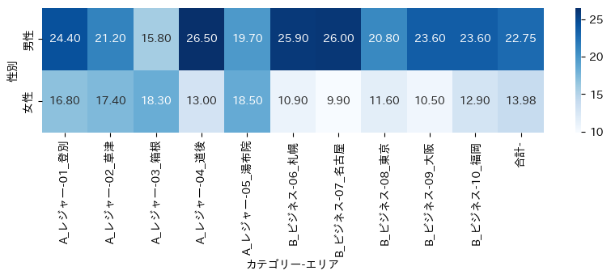

```python
import seaborn as sns
import matplotlib.pyplot as plt
import japanize_matplotlib

plt.figure(figsize=(10,2))
sns.heatmap(cross_df.loc[['男性','女性'],:], annot=True, fmt='.2f', cmap='Blues')
plt.show()
```

#### (5) 投稿者の傾向 (年代xエリア別、列ごとで100%)

```python
cross_df = pd.crosstab(df['年代'], [df['カテゴリー'],df['エリア']], margins=True, margins_name='合計', normalize='columns') * 100
display(cross_df.style.format('{:.2f}%'))
```

| カテゴリー エリア 年代 | A_レジャー 01_登別 | A_レジャー 02_草津 | A_レジャー 03_箱根 | A_レジャー 04_道後 | A_レジャー 05_湯布院 | B_ビジネス 06_札幌 | B_ビジネス 07_名古屋 | B_ビジネス 08_東京 | B_ビジネス 09_大阪 | B_ビジネス 10_福岡 | 合計 |
| --- | --- | --- | --- | --- | --- | --- | --- | --- | --- | --- | --- |
| 10代 | 0.00% | 0.10% | 0.20% | 0.00% | 0.00% | 0.10% | 0.00% | 0.00% | 0.10% | 0.00% | 0.05% |
| 120代 | 0.00% | 0.00% | 0.10% | 0.00% | 0.00% | 0.00% | 0.00% | 0.00% | 0.00% | 0.00% | 0.01% |
| 20代 | 1.90% | 2.20% | 3.50% | 0.90% | 1.90% | 0.80% | 1.70% | 1.40% | 1.60% | 1.30% | 1.72% |
| 30代 | 4.80% | 4.90% | 6.00% | 3.90% | 5.70% | 4.20% | 3.60% | 3.40% | 3.70% | 3.80% | 4.40% |
| 40代 | 7.10% | 6.80% | 5.80% | 7.50% | 7.20% | 8.20% | 9.10% | 8.30% | 7.20% | 6.50% | 7.37% |
| 50代 | 15.30% | 12.60% | 8.10% | 12.80% | 11.60% | 12.40% | 11.30% | 10.70% | 13.00% | 13.40% | 12.12% |
| 60代 | 9.70% | 9.30% | 7.10% | 11.00% | 9.30% | 9.60% | 9.00% | 7.50% | 7.20% | 9.70% | 8.94% |
| 70代 | 2.20% | 2.50% | 3.10% | 3.20% | 2.40% | 1.30% | 1.10% | 1.10% | 1.30% | 1.80% | 2.00% |
| 80代 | 0.20% | 0.20% | 0.20% | 0.20% | 0.10% | 0.20% | 0.00% | 0.00% | 0.00% | 0.00% | 0.11% |
| 90代 | 0.00% | 0.00% | 0.00% | 0.00% | 0.00% | 0.00% | 0.10% | 0.00% | 0.00% | 0.00% | 0.01% |
| na | 58.80% | 61.40% | 65.90% | 60.50% | 61.80% | 63.20% | 64.10% | 67.60% | 65.90% | 63.50% | 63.27% |

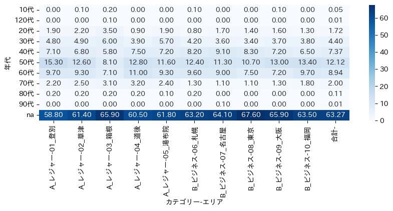

```python
import seaborn as sns
import matplotlib.pyplot as plt
import japanize_matplotlib

plt.figure(figsize=(10,3))
sns.heatmap(cross_df, annot=True, fmt='.2f', cmap='Blues')
plt.show()
```

`na` を除いてプロットする

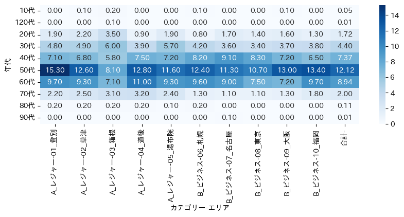

```python
import seaborn as sns
import matplotlib.pyplot as plt
import japanize_matplotlib

plt.figure(figsize=(10,3))
sns.heatmap(cross_df.loc[cross_df.index!='na',:], annot=True, fmt='.2f', cmap='Blues')
plt.show()
```

#### (6) 投稿者の傾向 (同伴者別xエリア別、列ごとで100%)

```python
cross_df = pd.crosstab(df['同伴者'], [df['カテゴリー'],df['エリア']], margins=True, margins_name='合計', normalize='columns') * 100
display(cross_df.loc[['一人','家族','恋人','友達','仕事仲間','その他'],:].style.format('{:.2f}%'))
```

| カテゴリー エリア 同伴者 | A_レジャー 01_登別 | A_レジャー 02_草津 | A_レジャー 03_箱根 | A_レジャー 04_道後 | A_レジャー 05_湯布院 | B_ビジネス 06_札幌 | B_ビジネス 07_名古屋 | B_ビジネス 08_東京 | B_ビジネス 09_大阪 | B_ビジネス 10_福岡 | 合計 |
| --- | --- | --- | --- | --- | --- | --- | --- | --- | --- | --- | --- |
| 一人 | 26.70% | 18.00% | 14.30% | 49.70% | 15.30% | 57.60% | 65.90% | 69.10% | 62.80% | 55.60% | 43.50% |
| 家族 | 60.80% | 63.50% | 64.50% | 38.30% | 64.70% | 31.70% | 25.30% | 21.00% | 26.20% | 32.50% | 42.85% |
| 恋人 | 5.50% | 10.50% | 12.00% | 3.90% | 9.90% | 2.90% | 3.30% | 3.60% | 3.10% | 3.10% | 5.78% |
| 友達 | 4.70% | 6.50% | 7.80% | 3.50% | 8.90% | 5.10% | 3.40% | 4.60% | 6.20% | 5.30% | 5.60% |
| 仕事仲間 | 1.70% | 0.70% | 0.50% | 3.70% | 0.50% | 2.00% | 1.40% | 1.10% | 1.40% | 3.10% | 1.61% |
| その他 | 0.60% | 0.80% | 0.90% | 0.90% | 0.70% | 0.70% | 0.70% | 0.60% | 0.30% | 0.40% | 0.66% |

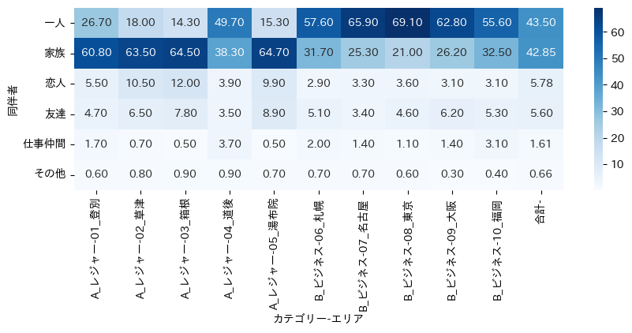

```python
import seaborn as sns
import matplotlib.pyplot as plt
import japanize_matplotlib

plt.figure(figsize=(10,3))
sns.heatmap(cross_df.loc[['一人','家族','恋人','友達','仕事仲間','その他'],:], annot=True, fmt='.2f', cmap='Blues')
plt.show()
```

#### (7) 数値評価の構成 (総合別xカテゴリ-エリア別、列ごとに100%)

```python
cross_df = pd.crosstab(df['総合'], [df['カテゴリー'],df['エリア']], margins=True, margins_name='合計', normalize='columns') * 100
display(cross_df.loc[[5,4,3,2,1],:].style.format('{:.2f}%'))
```

| カテゴリー エリア 総合 | A_レジャー 01_登別 | A_レジャー 02_草津 | A_レジャー 03_箱根 | A_レジャー 04_道後 | A_レジャー 05_湯布院 | B_ビジネス 06_札幌 | B_ビジネス 07_名古屋 | B_ビジネス 08_東京 | B_ビジネス 09_大阪 | B_ビジネス 10_福岡 | 合計 |
| --- | --- | --- | --- | --- | --- | --- | --- | --- | --- | --- | --- |
| 5 | 43.10% | 47.80% | 52.30% | 47.70% | 67.30% | 43.70% | 37.70% | 39.70% | 42.70% | 37.90% | 45.99% |
| 4 | 39.60% | 38.40% | 34.90% | 38.90% | 24.20% | 40.00% | 43.60% | 42.80% | 41.30% | 43.30% | 38.70% |
| 3 | 10.50% | 8.00% | 7.30% | 9.80% | 5.00% | 11.60% | 13.60% | 12.10% | 11.60% | 13.40% | 10.29% |
| 2 | 4.30% | 3.80% | 3.80% | 2.60% | 2.50% | 3.50% | 2.90% | 3.40% | 2.40% | 3.90% | 3.31% |
| 1 | 2.50% | 2.00% | 1.70% | 1.00% | 1.00% | 1.20% | 2.20% | 2.00% | 2.00% | 1.50% | 1.71% |

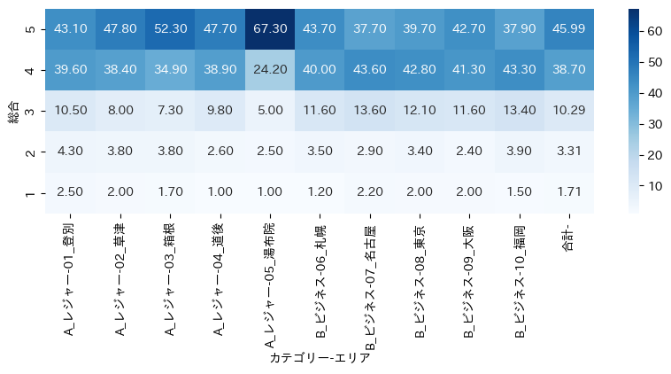

```python
import seaborn as sns
import matplotlib.pyplot as plt
import japanize_matplotlib

plt.figure(figsize=(10,3))
sns.heatmap(cross_df.loc[[5,4,3,2,1],:], annot=True, fmt='.2f', cmap='Blues')
plt.show()
```

#### (8) 数値評価の平均 (カテゴリ-エリア別x数値評価別)

```python
pivot_df = df.pivot_table(index=['カテゴリー','エリア'], values=['サービス','立地','部屋','設備・アメニティ','風呂','食事','総合'], margins=False, aggfunc='mean', dropna=True)
display(pivot_df.loc[:,['サービス','立地','部屋','設備・アメニティ','風呂','食事','総合']].style.format('{:.2f}').background_gradient(axis=None))
```

| カテゴリー | エリア | サービス | 立地 | 部屋 | 設備・アメニティ | 風呂 | 食事 | 総合 |
| --- | --- | --- | --- | --- | --- | --- | --- | --- |
| A_レジャー | 01_登別 | 4.08 | 4.24 | 3.98 | 3.94 | 4.28 | 4.13 | 4.17 |
|  | 02_草津 | 4.20 | 4.27 | 4.06 | 3.94 | 4.30 | 4.20 | 4.26 |
|  | 03_箱根 | 4.30 | 4.16 | 4.21 | 4.06 | 4.28 | 4.37 | 4.32 |
|  | 04_道後 | 4.20 | 4.35 | 4.10 | 4.02 | 4.08 | 4.20 | 4.30 |
|  | 05_湯布院 | 4.54 | 4.38 | 4.44 | 4.33 | 4.47 | 4.58 | 4.54 |
| B_ビジネス | 06_札幌 | 4.11 | 4.36 | 4.11 | 3.96 | 3.81 | 4.13 | 4.21 |
|  | 07_名古屋 | 3.98 | 4.26 | 3.99 | 3.88 | 3.76 | 3.97 | 4.12 |
|  | 08_東京 | 4.00 | 4.40 | 4.01 | 3.92 | 3.67 | 4.10 | 4.15 |
|  | 09_大阪 | 4.01 | 4.35 | 4.08 | 3.90 | 3.79 | 4.02 | 4.20 |
|  | 10_福岡 | 3.94 | 4.28 | 4.01 | 3.85 | 3.69 | 4.08 | 4.12 |

```python
pivot_df = df.pivot_table(index=['カテゴリー'], values=['サービス','立地','部屋','設備・アメニティ','風呂','食事','総合'], margins=False, aggfunc='mean', dropna=True)
display(pivot_df.loc[:,['サービス','立地','部屋','設備・アメニティ','風呂','食事','総合']].style.format('{:.2f}').background_gradient(axis=None))
```

| カテゴリー | サービス | 立地 | 部屋 | 設備・アメニティ | 風呂 | 食事 | 総合 |
| --- | --- | --- | --- | --- | --- | --- | --- |
| A_レジャー | 4.26 | 4.28 | 4.16 | 4.06 | 4.28 | 4.30 | 4.32 |
| B_ビジネス | 4.01 | 4.33 | 4.04 | 3.90 | 3.74 | 4.06 | 4.16 |

#### (9)数値評価の平均 (年代x性別)

20~30代

```python
pivot_df = df[df['年代'].isin(['20代','30代'])].pivot_table(index=['カテゴリー','性別'], values=['サービス','立地','部屋','設備・アメニティ','風呂','食事','総合'], margins=False, aggfunc='mean', dropna=True)
display(pivot_df.loc[(['A_レジャー','B_ビジネス'],['男性','女性']),['サービス','立地','部屋','設備・アメニティ','風呂','食事','総合']].style.format('{:.2f}').background_gradient(axis=None))
```

| カテゴリー | 性別 | サービス | 立地 | 部屋 | 設備・アメニティ | 風呂 | 食事 | 総合 |
| --- | --- | --- | --- | --- | --- | --- | --- | --- |
| A_レジャー | 男性 | 4.33 | 4.37 | 4.25 | 4.15 | 4.35 | 4.37 | 4.47 |
|  | 女性 | 4.46 | 4.46 | 4.40 | 4.37 | 4.49 | 4.46 | 4.51 |
| B_ビジネス | 男性 | 4.06 | 4.40 | 4.07 | 3.98 | 3.77 | 4.18 | 4.15 |
|  | 女性 | 4.24 | 4.39 | 4.24 | 4.05 | 3.85 | 4.20 | 4.27 |

40~50代

```python
pivot_df = df[df['年代'].isin(['40代','50代'])].pivot_table(index=['カテゴリー','性別'], values=['サービス','立地','部屋','設備・アメニティ','風呂','食事','総合'], margins=False, aggfunc='mean', dropna=True)
display(pivot_df.loc[(['A_レジャー','B_ビジネス'],['男性','女性']),['サービス','立地','部屋','設備・アメニティ','風呂','食事','総合']].style.format('{:.2f}').background_gradient(axis=None))
```

| カテゴリー | 性別 | サービス | 立地 | 部屋 | 設備・アメニティ | 風呂 | 食事 | 総合 |
| --- | --- | --- | --- | --- | --- | --- | --- | --- |
| A_レジャー | 男性 | 4.20 | 4.32 | 4.09 | 4.02 | 4.24 | 4.29 | 4.33 |
|  | 女性 | 4.48 | 4.45 | 4.36 | 4.24 | 4.47 | 4.41 | 4.48 |
| B_ビジネス | 男性 | 3.95 | 4.28 | 4.00 | 3.85 | 3.72 | 3.97 | 4.16 |
|  | 女性 | 4.22 | 4.48 | 4.26 | 4.08 | 3.97 | 4.32 | 4.37 |

60~80代

```python
pivot_df = df[df['年代'].isin(['60代','70代','80代'])].pivot_table(index=['カテゴリー','性別'], values=['サービス','立地','部屋','設備・アメニティ','風呂','食事','総合'], margins=False, aggfunc='mean', dropna=True)
display(pivot_df.loc[(['A_レジャー','B_ビジネス'],['男性','女性']),['サービス','立地','部屋','設備・アメニティ','風呂','食事','総合']].style.format('{:.2f}').background_gradient(axis=None))
```

| カテゴリー | 性別 | サービス | 立地 | 部屋 | 設備・アメニティ | 風呂 | 食事 | 総合 |
| --- | --- | --- | --- | --- | --- | --- | --- | --- |
| A_レジャー | 男性 | 4.18 | 4.22 | 4.11 | 3.97 | 4.25 | 4.22 | 4.25 |
|  | 女性 | 4.27 | 4.24 | 4.15 | 4.08 | 4.30 | 4.24 | 4.27 |
| B_ビジネス | 男性 | 3.81 | 4.30 | 3.90 | 3.70 | 3.70 | 3.89 | 4.08 |
|  | 女性 | 4.21 | 4.41 | 4.38 | 3.96 | 3.92 | 4.08 | 4.31 |